# Team 3 Lab-1 Write-Up

Emma T-S, Zoe R, Madi S

2023-04-18

```r
library(tidyverse)
library(forecast)
library(here)
```

```r
library(cowplot)
```

# Team Members

Team member names: Zoe Rand (QERM), Madison Shipley (SAFS), Emma Timmins-Schiffman (Genome Sci)

# Data

We chose to work with all data to compare ability of the ARIMA models to forecast across different patterns of population dynamics and different sizes of training data sets.

```r
#reading in data
#ruggerone_data <- readRDS(here::here("Lab-1", "Data_Images", "ruggerone_data.rds"))

#The above code was not working for me, so I've added this in temporarily (MS)
ruggerone_data <- readRDS("C:/GitHub/fish550-2023/Lab-1/Data_Images/ruggerone_data.rds")
```

# Question your team will address

1. If we approached these data as stock managers, how confident could we be in projected return data 5, 10, or 20 years into the future?
2. What types of population patterns are ARIMA models best suited for?
3. Is one species or region “easier” to forecast than others?

# Initial plan

For each species we will subset by region and test for stationarity. Then for forecast levels of 5, 10, and 20 years for each region, we will run auto-arima. We will look at forecasts and accuracy using RMSE to determine what level of for asting could be appropriate when considering management utility.

We will pick a couple of regions for each species to demonstrate ACF and PACF, and look through model results for any residuals.

# What we actually did

It was harder to compare models across species and regions than we assumed. We created functions to help streamline this process. Also after researching forecast accuracy metrics, we decided to use MASE as a metric instead of RMSE. It was difficult to decipher why some regions were more easily forecasted and others returned unreliable results. Additionally, each species had different dynamics, and some variable methods were applied in order to find a model that worked.

Subset and format the data to analyze just sockeye.

```r
SockByRegion<-ruggerone_data %>%
  filter(region != "japan") %>%
  filter(region != "korea") %>%
  group_by(species, region, year) %>%
  summarize(total = sum(returns, na.rm=TRUE)) %>%
  mutate(lnreturns = log(total)) %>%
  filter(species == "sockeye")
```

Create a time series object and train the data on the first 59 years of data; forecast the last 5 years.

```r
sockeye.ts<-ts(SockByRegion$lnreturns, start=SockByRegion$year[1])

train.sockeye<-window(sockeye.ts, start=1952, end=2010)
test.sockeye<-window(sockeye.ts, start=2011, end=2015)
```

Assess the ACF and PACF of the training data set.

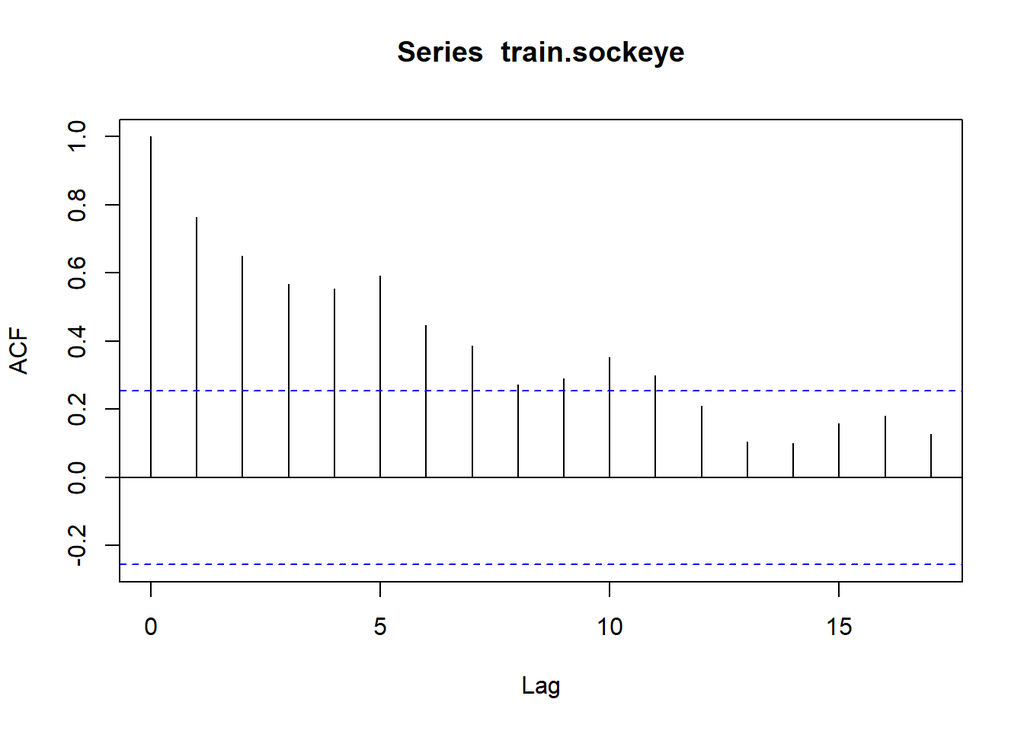

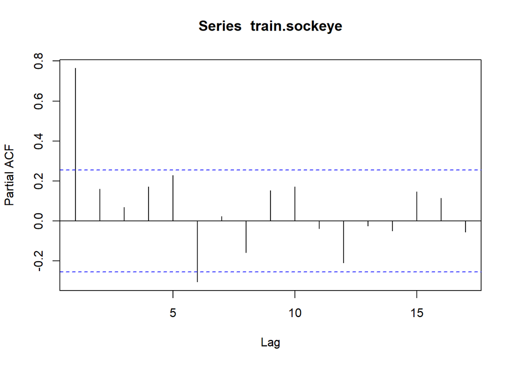

```r
fit <- forecast::auto.arima(train.sockeye, trace=T)
```

```
##
##  ARIMA(2,1,2) with drift         : Inf
##  ARIMA(0,1,0) with drift         : 61.95027
##  ARIMA(1,1,0) with drift         : 60.11204
##  ARIMA(0,1,1) with drift         : 57.27974
##  ARIMA(0,1,0)                    : 59.87487
##  ARIMA(1,1,1) with drift         : Inf
##  ARIMA(0,1,2) with drift         : 57.23854
##  ARIMA(1,1,2) with drift         : Inf
##  ARIMA(0,1,3) with drift         : Inf
##  ARIMA(1,1,3) with drift         : Inf
##  ARIMA(0,1,2)                    : 55.53198
##  ARIMA(0,1,1)                    : 55.33664
##  ARIMA(1,1,1)                    : 55.19379
##  ARIMA(1,1,0)                    : 57.99975
##  ARIMA(2,1,1)                    : 57.46972
##  ARIMA(1,1,2)                    : 57.48549
##  ARIMA(2,1,0)                    : 58.91271
##  ARIMA(2,1,2)                    : Inf
##
##  Best model: ARIMA(1,1,1)
```

```r
fit.final.sock<-forecast::auto.arima(train.sockeye, approximation = F, stepwise = F)
```

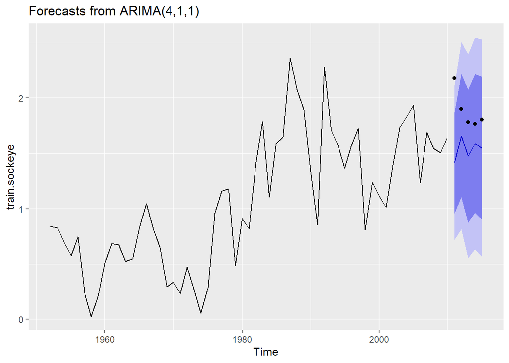

## Assess how well forecasting performs for sockeye returns by region

Create objects needed for plotting.

```r
regions<-unique(SockByRegion$region)
regionskey<-c("Cook Inlet", "E. Kamchatka", "Kodiak", "Russia", "N.British Columbia",
              "Prince William Sound", "S. Alaska Pen.", "S. British Columbia", "SE Alaska", "W. Kamchatka", "Washington", "W. Alaska")
names(regionskey)<-regions
forecastlevels<-c(5, 10, 20)
Allcombs<-expand_grid(regions, forecastlevels)
```

Plot ACF and PACF for each region.

```r
ACFandPACF<-function(reg){
  Sockdat<-SockByRegion %>% filter(region == reg)
  #create time series
  datts <- ts(Sockdat$lnreturns, start=Sockdat$year[1])
  return(list(a = acf(datts, plot = FALSE), p = pacf(datts, plot = FALSE)))
}
```

```r
DiagPlots<-lapply(regions, ACFandPACF)
names(DiagPlots)<-regions
```

ACF plots

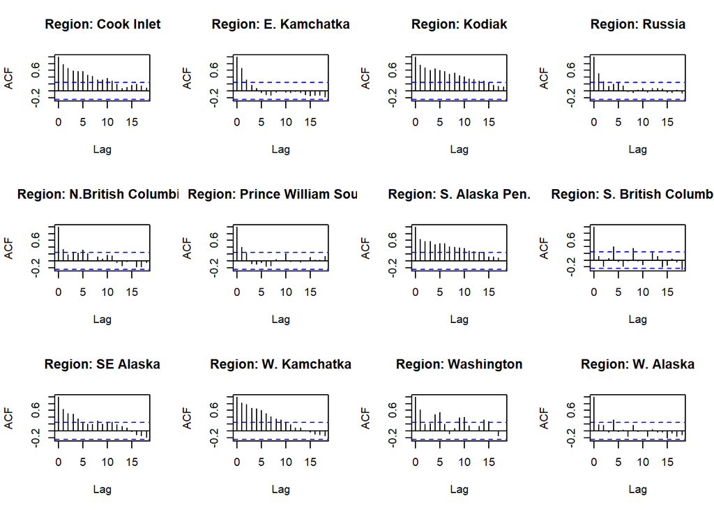

PACF plots

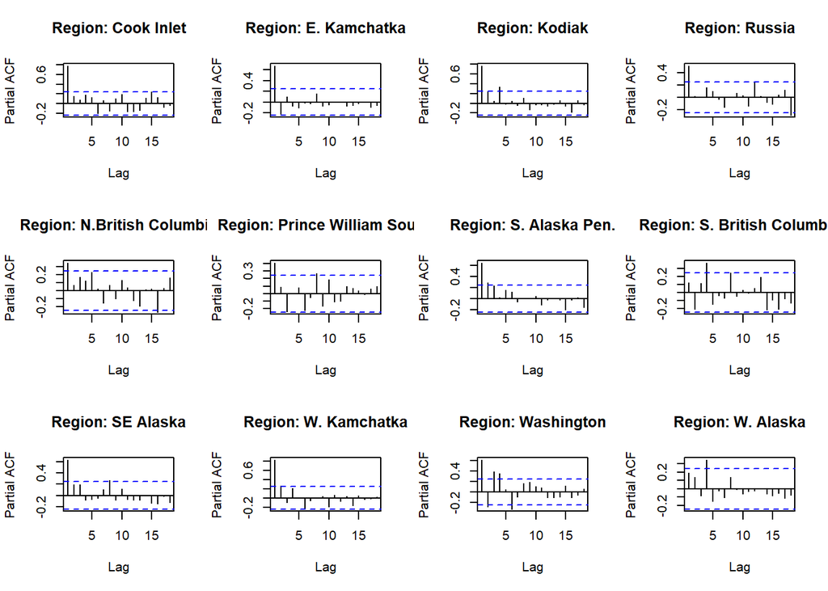

Fit ARIMA models to each region.

```r
FitModFunction<-function(reg, forelevel){
  #filter region
  Sockdat<-SockByRegion %>% filter(region == reg)
  #create time series
  datts <- ts(Sockdat$lnreturns, start=Sockdat$year[1]) #this assumes the first year in data is the start of the time series (they are in order)
  cutoff<-2015-forelevel
  train <- window(datts, 1952, cutoff)
  test <- window(datts, cutoff+1, 2015)

  mod <- auto.arima(train)

  #testing to be sure that this is the best model (is the best mode the simplest if it is within 2 AIC values?)
  trace <- capture.output({
    # assign so it doesn't pollute the output
    model <- auto.arima(datts, trace = TRUE)
  })
  con    <- textConnection(trace)
  models <- read.table(con, sep=":")
  close(con)

  #getting the "best models" that are within 2 AIC units
  BestMods<-models%>% filter(row_number() != nrow(models)) %>% mutate(AIC = replace(V2, V2 == "Inf", 99999), AIC = as.numeric(AIC), DeltaAIC = AIC-min(AIC)) %>% filter(DeltaAIC <= 2.0)
  for(i in 1:nrow(BestMods)){
    BestMods$Mod[i]<-strsplit(strsplit(strsplit(BestMods$V1[i], "[(]")[[1]][2], "[)]")[[1]][1],"[,]")
    BestMods$npar[i]<-sum(as.numeric(BestMods$Mod[i][[1]][c(1,3)]))
    if(strsplit(strsplit(BestMods$V1[i], "[(]")[[1]][2], "[)]")[[1]][2] == " with drift         "){
      BestMods$npar[i] = BestMods$npar[i] + 1
    }
  }

  New<-BestMods %>% filter(npar == min(npar))
  if(0 %in% New$DeltaAIC){
      #auto arima picked the best model
      res<-accuracy(forecast(mod, h=forelevel), test)[2,"MASE"] #test set MASE
  }else{
      #of the models with the fewest parameters, pick the lowest AIC
      newmod<-New %>% filter(AIC == min(AIC)) %>% select(Mod)
      mod<-Arima(train, order = as.numeric(strsplit(newmod$Mod[[1]], "[,]")), include.constant = TRUE)
      res<-accuracy(forecast(mod, h=forelevel), test)[2,"MASE"] #test set MASE
    }

  return(list(Fit = mod, MASE = res, Bm = BestMods)) #include best mods for testing to see that it's doing what I want
}
RegionModsSock<-mapply(FitModFunction, Allcombs$regions, Allcombs$forecastlevels, SIMPLIFY = FALSE)
```

Extract MASE for comparisons of models across regions.

```r
RegionMASESock<-sapply(RegionModsSock, function(x){y<-x$MASE})
RegionBestModSock<-sapply(RegionModsSock, function(x){y<-as.character(x$Fit)})

ResultsTableSock<-Allcombs %>% add_column(Model = RegionBestModSock, MASE = RegionMASESock)
```

How well does auto.arima do in choosing a model? Is it different from what we would choose looking at ACF and PACF? For Cook Inlet, auto.arima selected ARIMA(4,1,1), but PACF has a significant lag at 6 and ACF trails off.

```r
sock.ci<-subset(SockByRegion, region=='ci')
ci.ts<-ts(sock.ci$lnreturns, start=sock.ci$year[1])
forecast::ndiffs(ci.ts, test='adf')
```

```
## [1] 1
```

```r
forecast::ndiffs(ci.ts, test='kpss')
```

```
## [1] 1
```

```r
train.ci5<-window(ci.ts, start=1952, end=2010)
test.ci5<-window(ci.ts, start=2011, end=2015)
ci.final5<-forecast::auto.arima(train.ci5, approximation = F, stepwise = F)
accuracy(forecast(ci.final5, h=5), test.ci5)
```

```
##                      ME      RMSE       MAE       MPE     MAPE      MASE
## Training set 0.02471079 0.3370305 0.2702999 -38.06705 62.87923 0.8967555
## Test set     0.34919358 0.4082214 0.3491936  17.84353 17.84353 1.1584957
##                      ACF1 Theil's U
## Training set  0.008040561        NA
## Test set     -0.080588177  1.829245
```